# Single T-cell Analysis by Rna-seq and Tcr TRACking (Startrac)

2019-06-14

#### Abstract

Instructions on how to use Startrac

#### Package

Startrac 0.1.0

# 1 Introduction

# 2 Quick start

We load the Startrac package and other packages for visualization.

```r
library("Startrac")
library("tictoc")
library("ggpubr")
library("ggplot2")
library("ComplexHeatmap")
library("RColorBrewer")
library("circlize")
```

Then we read in the example data. The input to Startrac should be a data.frame for which the columns ‘clone.id’, ‘patient’, ‘majorCluster’ and ‘loc’ are required.

```r
dat.file <- system.file("extdata/example.cloneDat.Zhang2018.txt",
                        package = "Startrac")
in.dat <- read.table(dat.file,stringsAsFactors = F,head=T)
head(in.dat)
```

```
##         Cell_Name            clone.id clone.status patient sampleType stype
## 1  TTH36-20180123 CRC.P0123_C000002:9       Clonal   P0123        TTH   CD4
## 2 TP7170-20180123 CRC.P0123_C000002:9       Clonal   P0123        TP7   CD4
## 3  TTH85-20180123 CRC.P0123_C000002:9       Clonal   P0123        TTH   CD4
## 4 TTH128-20180123 CRC.P0123_C000002:9       Clonal   P0123        TTH   CD4
## 5 TP7111-20180123 CRC.P0123_C000002:9       Clonal   P0123        TP7   CD4
## 6  TP752-20180123 CRC.P0123_C000003:2       Clonal   P0123        TP7   CD4
##    majorCluster loc
## 1  CD4_C07-GZMK   T
## 2  CD4_C07-GZMK   T
## 3  CD4_C07-GZMK   T
## 4  CD4_C07-GZMK   T
## 5  CD4_C07-GZMK   T
## 6 CD4_C05-CXCR6   T
```

Run the pipeline using below command to obtain the indices of the entire data set and data from each patient.

```r
tic("Startrac.run")
out <- Startrac.run(in.dat, proj="CRC",verbose=F)
```

```
## [2019-06-14 15:25:29] initialize Startrac ...
## [2019-06-14 15:25:29] calculate startrac index ...
## [2019-06-14 15:25:29] calculate pairwise index ...
## [2019-06-14 15:25:30] calculate indices of each patient ...
## [2019-06-14 15:25:34] collect result
## [2019-06-14 15:25:34] return
```

```r
toc()
```

```
## Startrac.run: 5.07 sec elapsed
```

# 3 Visualization

## 3.1 cluster level index of all data

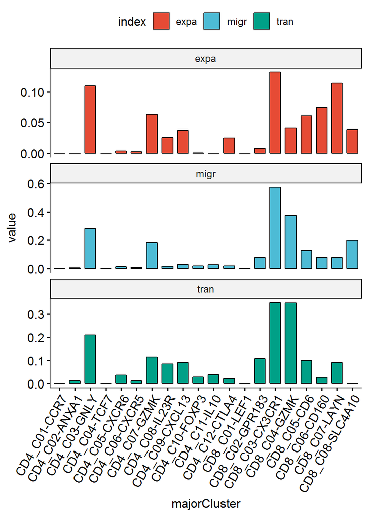

```r
plot(out,index.type="cluster.all",byPatient=F)
```

## 3.2 cluster level index by patients.

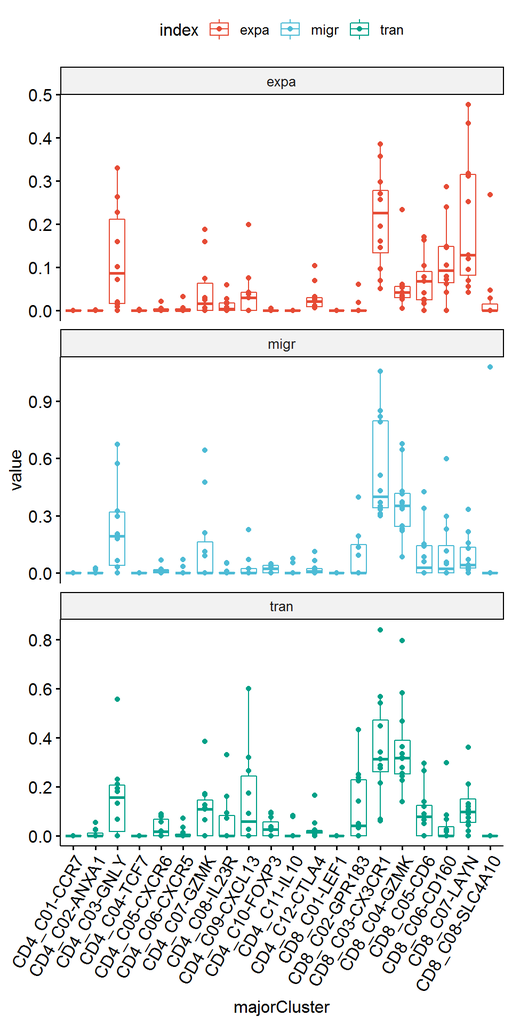

```r
plot(out,index.type="cluster.all",byPatient=T)
```

## 3.3 pairwise index of all data

migration index between two locations

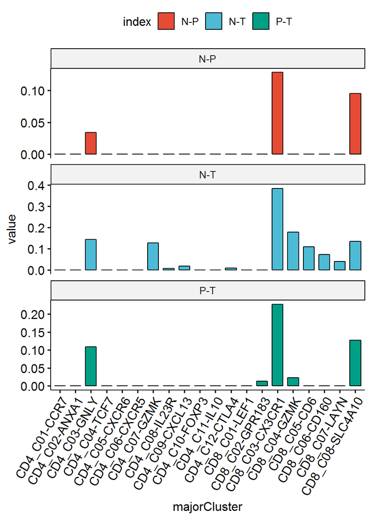

```r
plot(out,index.type="pairwise.migr",byPatient=F)
```

transition index between two major clusters

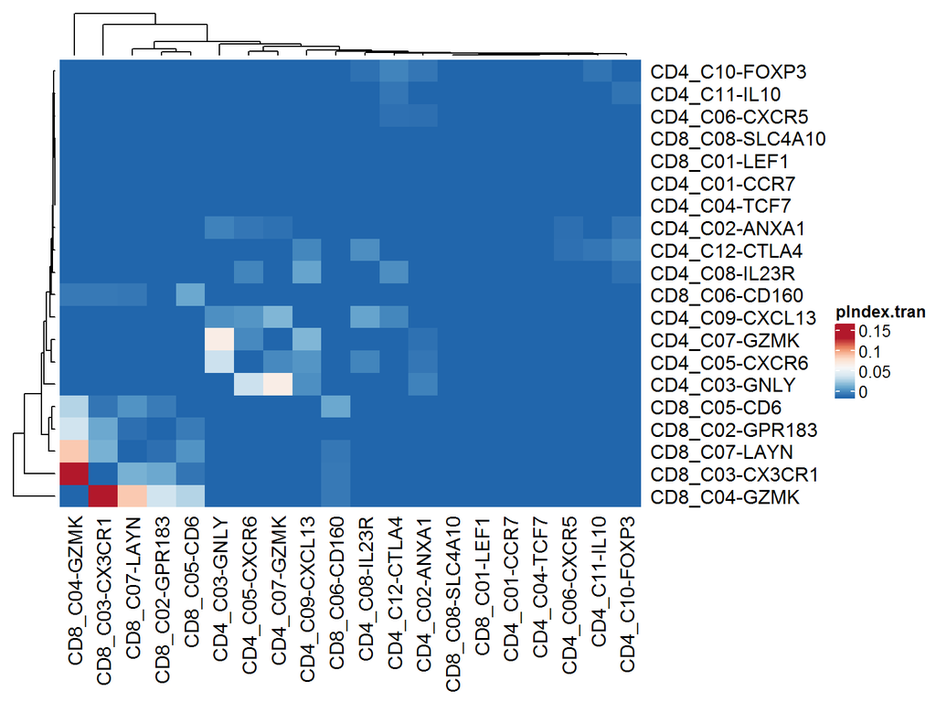

```r
plot(out,index.type="pairwise.tran",byPatient=T)
```

# 4 Step by Step

Construct the Startrac object using the example data. The input data and some derived information are stored in slots, for exmaple `cell.data` for the original input data, `clonotype.dist.cluster` for the distribution of clone along major clusters, `clonotype.dist.loc` for the distribution of clone along locations. The parameter `aid` is used to identify the dataset, it can be the project name or patient id.

```r
dat.file <- system.file("extdata/example.cloneDat.Zhang2018.txt",
                        package = "Startrac")
in.dat <- read.table(dat.file,stringsAsFactors = F,head=T)
obj <- new("Startrac",in.dat,aid="CRC")
```

We can examine these information

```r
obj@clonotype.dist.cluster[1:3,1:4]
```

```
##                      majorCluster
## clone.id              CD4_C01-CCR7 CD4_C02-ANXA1 CD4_C03-GNLY CD4_C04-TCF7
##   CRC.P0123_C000002:9            0             0            0            0
##   CRC.P0123_C000003:2            0             0            0            0
##   CRC.P0123_C000010:1            0             0            0            0
```

```r
obj@clonotype.dist.loc[1:3,]
```

```
##                      loc
## clone.id              N P T
##   CRC.P0123_C000002:9 0 0 7
##   CRC.P0123_C000003:2 0 0 2
##   CRC.P0123_C000010:1 0 0 1
```

Calculate the cluster level index. The cluster level indices are stored in slot `cluster.data`.

```r
obj <- calIndex(obj)
head(obj@cluster.data)
```

```
##               aid  majorCluster         expa        migr       tran
## CD4_C01-CCR7  CRC  CD4_C01-CCR7 0.0000000000 0.000000000 0.00000000
## CD4_C02-ANXA1 CRC CD4_C02-ANXA1 0.0002825175 0.005941754 0.01142946
## CD4_C03-GNLY  CRC  CD4_C03-GNLY 0.1100916187 0.283058520 0.20964640
## CD4_C04-TCF7  CRC  CD4_C04-TCF7 0.0001853295 0.000000000 0.00000000
## CD4_C05-CXCR6 CRC CD4_C05-CXCR6 0.0036856538 0.014721526 0.03749719
## CD4_C06-CXCR5 CRC CD4_C06-CXCR5 0.0027706317 0.007936508 0.01158054
```

Calculate the pairwise index.

```r
tic("pIndex")
obj <- pIndex(obj)
toc()
```

```
## pIndex: 1.41 sec elapsed
```

These indices are stored in slot `pIndex.migr` and `pIndex.tran`.

```r
head(obj@pIndex.migr)
```

```
##   aid  majorCluster        N-P       N-T     P-T
## 1 CRC  CD4_C01-CCR7 0.00000000 0.0000000 0.00000
## 2 CRC CD4_C02-ANXA1 0.00000000 0.0000000 0.00000
## 3 CRC  CD4_C03-GNLY 0.03379301 0.1428571 0.10904
## 4 CRC  CD4_C04-TCF7 0.00000000 0.0000000 0.00000
## 5 CRC CD4_C05-CXCR6 0.00000000 0.0000000 0.00000
## 6 CRC CD4_C06-CXCR5 0.00000000 0.0000000 0.00000
```

```r
obj@pIndex.tran[1:3,1:6]
```

```
##   aid  majorCluster CD4_C01-CCR7 CD4_C02-ANXA1 CD4_C03-GNLY CD4_C04-TCF7
## 1 CRC  CD4_C01-CCR7           NA   0.000000000  0.000000000            0
## 2 CRC CD4_C02-ANXA1            0            NA  0.008521527            0
## 3 CRC  CD4_C03-GNLY            0   0.008521527           NA            0
```